# Project2 Phase 2

Ziad Al Bkhetan, Neven Piculjan, Naveen Mupparapu

January 7, 2016

# Internet of Things - Introduction

In the second phase we should cluster the records in the dataset, then try to charactrize these clusters and find some intersting patterns for these visits.

We Assumed That the visit is the duration between the minimum date and maximum date for the same visitor in the same station, in the same day.

we used a dataset contains 6700000 records, and we analysed it, just to make the performance faster.

for Hierarchical Clustering we used smaller dataset for reasons related to the execution time and memory limitation.

# Data Loading And Cleaning

In this step we will prepare the data set to start analysis phase, we assumed that the maybe the dataset is not sorted, so we sort it based on the visitor and date.

We removed the records when the visitor is -1, because they are incorrect data. we used two datasets, one of them for the stations : ‘cnk02a’, ‘cnk02b’, ‘cnk03’, ‘cnk05’ the second dataset for ‘cnk02a’, ‘cnk02b’, ‘cnk03’, ‘cnk05’, ‘cnk06’, ‘cnk07’, ‘cnk09’, ‘cnk10’

```r
library(tidyr)
library(dplyr)
library(ggplot2)
library(cluster)
library(caret)
load('D:/MSc Computer science and informatics/3rd semester/Data Mining - Advances/Lab Projects/Project 2/SmallLogs_z.rda')

# Cleaning
# all stations : c('cnk02a', 'cnk02b', 'cnk03', 'cnk05', 'cnk06',  'cnk07', 'cnk09', 'cnk10')
smallLogs = filter(smallLogs, visitor != -1)
orderedData <- filter(smallLogs, station %in% c('cnk02a', 'cnk02b', 'cnk03', 'cnk05'))
orderedData = arrange(orderedData, visitor, station, date)
```

# Prepare The Final DataSet

in this step we will fetch all needed data for analysis and visualization, and the most important for us are: Visitor ID, Station, Consumed Time, Day, and Hour.

we grouped all the data based on the visitor and the station and the visit day, because each visit should be in one day, and the card is valid for one day.

After that we calculated the visit duration as the difference between the minimum and maximum time for each visitor in each station in the same day, this difference is calculated in minutes.

For Clustering, We decided to cluster these visits based on two different datasets

The First one is a normalized dataset, and we will use these variables to calculate the distances

- the consumed time in each visit
- Start Time

We Normalized the Data, to reduce the effect of variables values range when calculate the distnces.

The second Dataset, using the interactions in each visit, so we put one if the page was visited, and zero if not, then we calcualte the ditances based on the similar visited pages.

```r
orderedDataFinal = orderedData %>%
  group_by(Visitor=visitor, dat=format(date, format="%Y:%m:%d") , Station=station) %>%
  summarise(
    start_time = min(date),
    send_time = max(date),
    Cons_time = difftime(max(date), min(date),units='mins'),
    WDay = as.POSIXlt(min(date))$wday,
    THour = as.POSIXlt(min(date))$hour
    )

orderedDataFinal$start_time_hms <- as.POSIXlt(orderedDataFinal$start_time)$hour * 3600 + as.POSIXlt(orderedDataFinal$start_time)$min * 60 + as.POSIXlt(orderedDataFinal$start_time)$sec

finalData <- orderedDataFinal
finalData$Cons_time <- as.numeric(finalData$Cons_time)
finalData$Station <- factor(finalData$Station)
finalData <- filter(finalData, Cons_time > 1)

# Create Normalized Variables based on the original Variables

finalData$start_date_n = as.numeric(finalData$start_time)
finalData$Cons_time_n = as.numeric(finalData$Cons_time)
finalData$WDay_n = as.numeric(finalData$WDay)
finalData$THour_n = as.numeric(finalData$THour)

# Data normalization
normalize <- function(x) {
  scale(x)
}


normalized_data <- as.data.frame(lapply(finalData[, 9:13], normalize))
finalData$start_date_n <- normalized_data$start_date_n
finalData$Cons_time_n <- normalized_data$Cons_time_n
finalData$WDay_n <- normalized_data$WDay_n
finalData$THour_n <- normalized_data$THour_n
finalData$start_time_hms_n <- normalized_data$start_time_hms

# Using the interactions for clustering

finalData_2 =  smallLogs
rm(smallLogs)
finalData_2$scene <- substring(finalData_2$scene, regexpr("sceneId=", finalData_2$scene) + 8, regexpr(">", finalData_2$scene) - 1)
finalData_2$dat=format(finalData_2$date, format="%Y:%m:%d")

finalData_for_interactions = finalData_2 %>%
  group_by(Visitor=visitor, scene) %>%
  summarise(count = n()) %>%
  spread(scene, count, fill=0)

rm(normalized_data, finalData_2, orderedData)
```

# Clustering Using the normalized Dataset

## K-Means

Starting with K-means clustering, we will try to cluster the observations into different numbers of clusters, and compare the averave silhouette values

```r
clus_range <- seq(3, 10, 1)
k_meanslst <- list()
for (i in clus_range)
{
  k_meanslst[[i - 2]] <- kmeans(finalData[,c("start_time_hms_n","Cons_time_n")], i)
}
#k_meanslst <- k_meanslst [!sapply(k_meanslst, is.null)]

#des <- daisy(as.matrix(finalData[,c("start_time_hms","Cons_time_n")]))
#kmeans_res <- sapply(k_meanslst, function(x) mean(silhouette(x$cl, des)[, 3]))
#plot(clus_range, kmeans_res)
```

## Choosen K-Means Model

Here we selected the model which cluster the data into four clusters, then we visualized the data based on the start time and the consumed time.

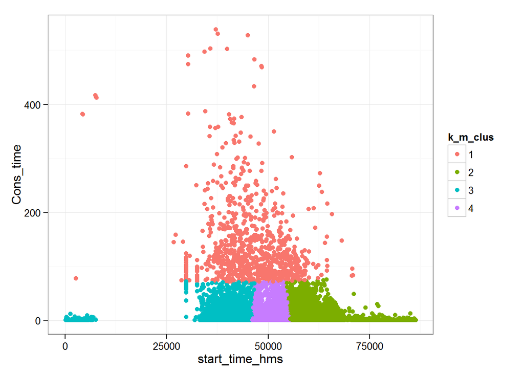

```r
#k_meanslst [[match(max(kmeans_res),kmeans_res)]]
k_means_mod <- k_meanslst [[2]]
finalData$k_m_clus = factor(k_means_mod$cluster)

ggplot(finalData, aes(start_time_hms, Cons_time)) +
  geom_point(aes(color=k_m_clus), size=2)+
  theme_bw()
```

We can see from this plot that the data is clustered into four different clusters which are well separated.

so we can summarize that we have four clusters:

- one of them contain the long period visits
- second one for the morning time befor 12
- third one for Afternoon time from 12 to 15
- fouth one for after evening after 15

## Statistics

here we will show some statistical information extracted from the these clusters

### Visits in each Cluster

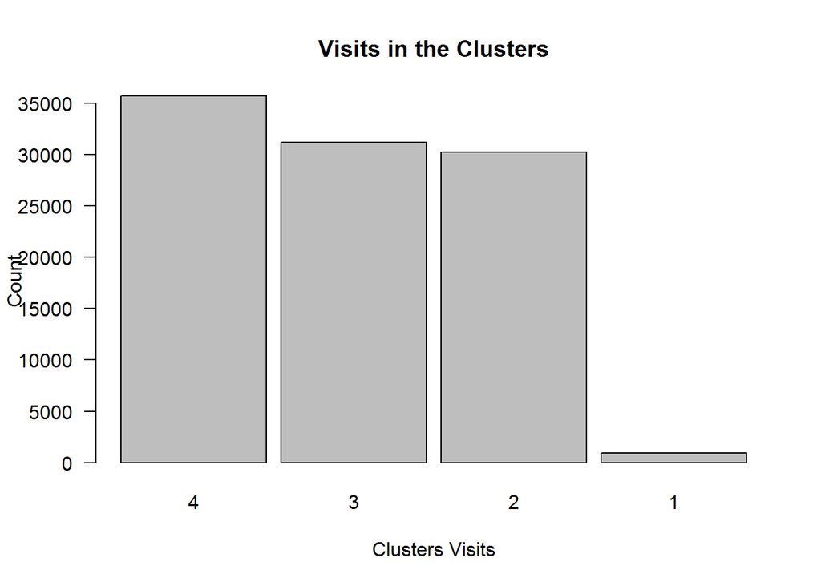

```r
WeeksDays <- c("Sun", "Mon", "Tue", "Wed", "Thu", "Fri", "Sat")
finalData$THour <- factor(finalData$THour)

vis_data = finalData %>%
  group_by(k_m_clus) %>%
  summarise(
    s_count = n()
  )
x = vis_data$s_count
names(x) <- vis_data$k_m_clus
x <- sort(x, decreasing = TRUE)
barplot(x, main="Visits in the Clusters", xlab="Clusters Visits", ylab = "Count", horiz = FALSE, las = 1, space = c(0.1, .2))
```

### Visitors distribution in the Clusters

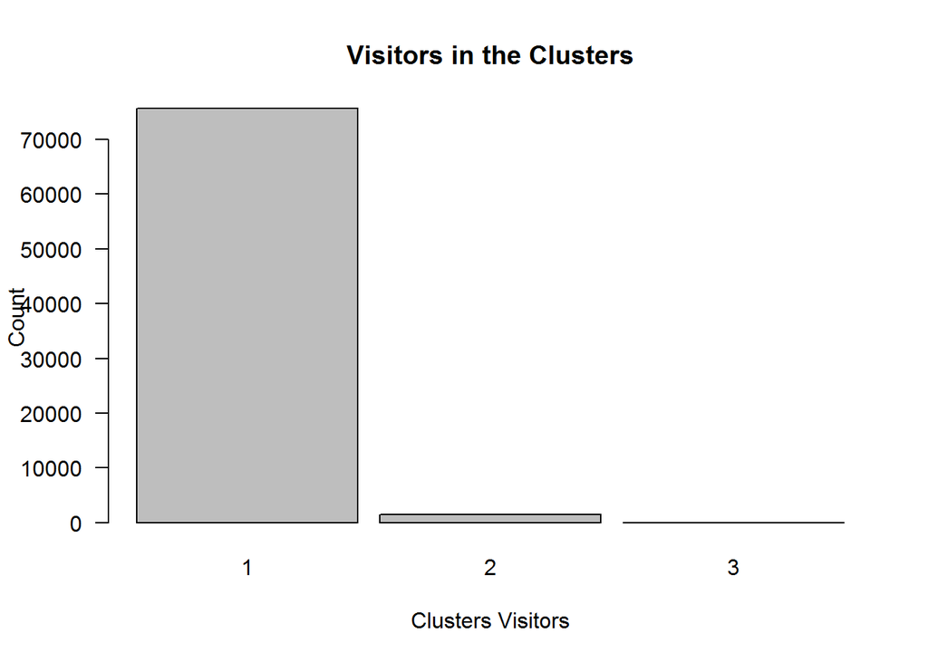

```r
vis_data = finalData %>%
  group_by(Visitor) %>%
  summarise(
    s_count = length(unique(k_m_clus))
  )

vis_data = vis_data %>%
  group_by(s_count) %>%
  summarise(
    s_count_n = n()
  )

x = vis_data$s_count_n
names(x) <- vis_data$s_count
x <- sort(x, decreasing = TRUE)
barplot(x, main="Visitors in the Clusters", xlab="Clusters Visitors", ylab = "Count", horiz = FALSE, las = 1, space = c(0.1, .2))
```

the first bar ilustrate how many different visitors belong to one cluster. the second how many visitors belong to two clusters, the third for three and the fourth for four clusters.

this plot shows that most visitors (not visits) belongs to one clusters, and few of them belongs to two or three of these clusters, but no visitor belongs to all clusters. this means that most visitors have one prefered patterns to use these stations, and few of them have two or three different patterns to use the stations

### Stations in each Cluster

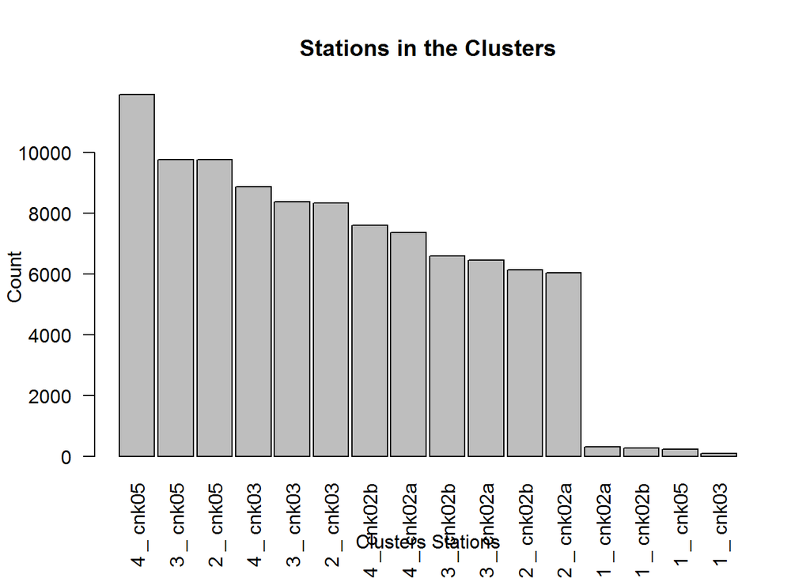

```r
vis_data = finalData %>%
  group_by(k_m_clus, Station) %>%
  summarise(
    s_count = n()
  )
x = vis_data$s_count
names(x) <- paste(vis_data$k_m_clus, "_", vis_data$Station)
x <- sort(x, decreasing = TRUE)
barplot(x, main="Stations in the Clusters", xlab="Clusters Stations", ylab = "Count", horiz = FALSE, las =2, space = c(0.1, .2))
```

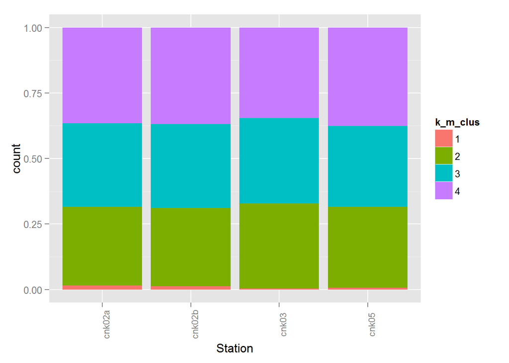

```r
ggplot(data=finalData,aes(x=Station,fill=k_m_clus))+
  geom_bar(position = "fill")+theme(axis.text.x=element_text(angle=90,size=9))
```

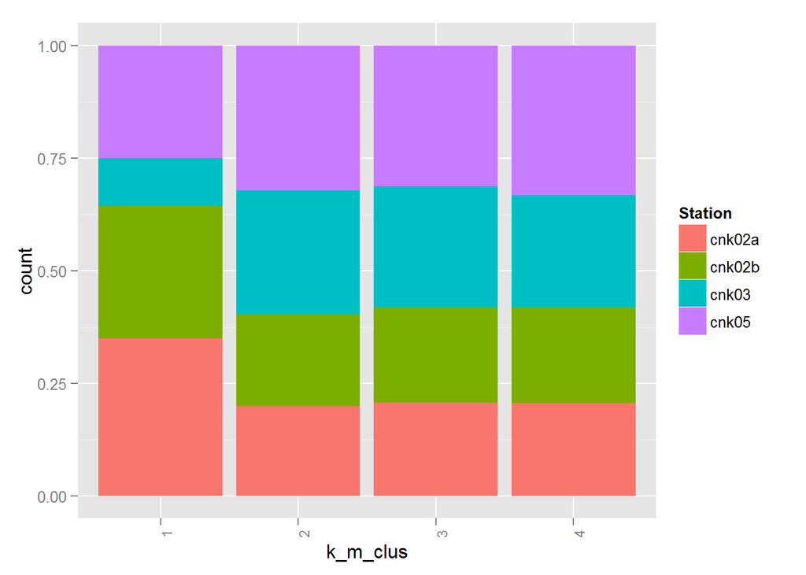

```r
ggplot(data=finalData,aes(x=k_m_clus,fill=Station))+
  geom_bar(position = "fill")+theme(axis.text.x=element_text(angle=90,size=9))
```

and we can find that all stations exist in all clusters, so all the vistors in these stations have different pattern to use the station.

### Start Hours in each Cluster

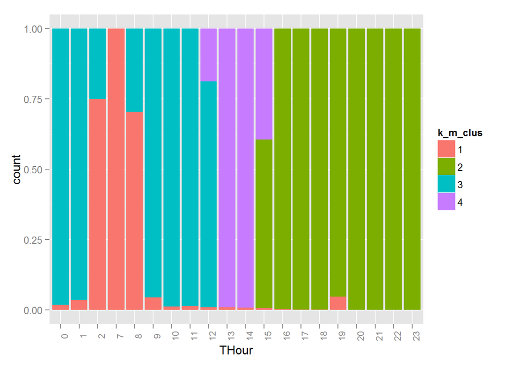

```r
ggplot(data=finalData,aes(x=THour,fill=k_m_clus))+
  geom_bar(position = "fill")+theme(axis.text.x=element_text(angle=90,size=9))
```

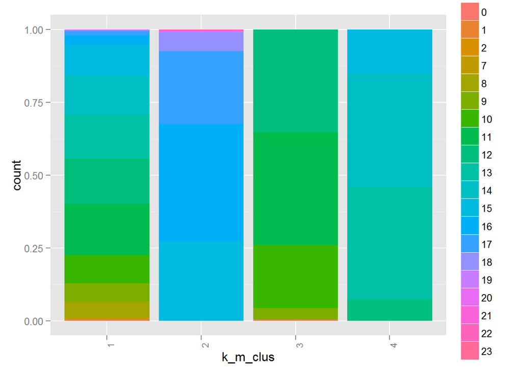

```r
ggplot(data=finalData,aes(x=k_m_clus,fill=THour))+
  geom_bar(position = "fill")+theme(axis.text.x=element_text(angle=90,size=9))
```

we can see the distribution of the data in each cluster based on the hour.

### Days in each Cluster

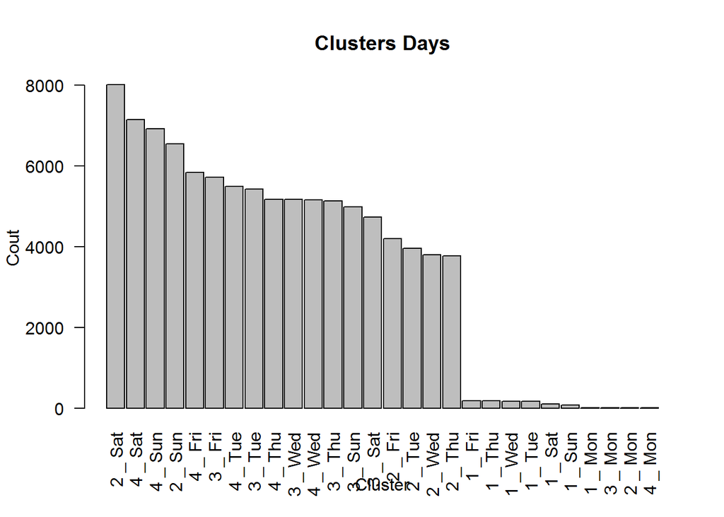

```r
vis_data = finalData %>%
  group_by(k_m_clus, WDay) %>%
  summarise(
    s_count = n()
  )

x = vis_data$s_count
names(x) <- paste(vis_data$k_m_clus, "_", WeeksDays[(vis_data$WDay) + 1])
x <- sort(x, decreasing = TRUE)
barplot(x, main="Clusters Days", xlab="Cluster", ylab = "Cout", horiz = FALSE, las = 2, space = c(0.1, .2))
```

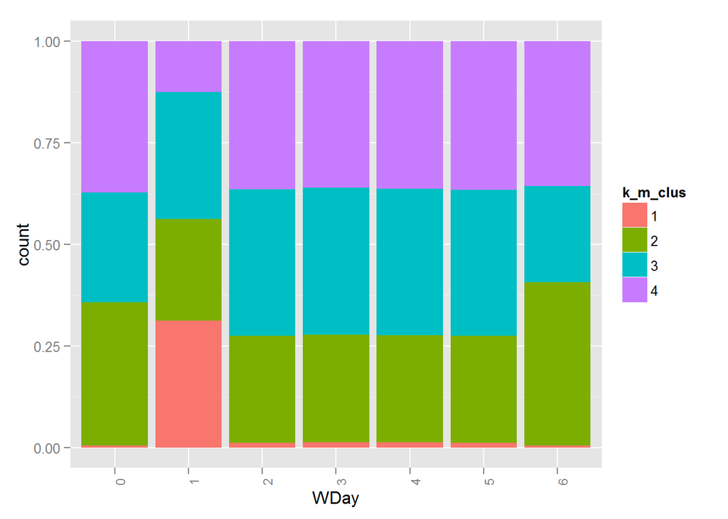

```r
finalData$WDay <- factor(finalData$WDay)

ggplot(data=finalData,aes(x=WDay,fill=k_m_clus))+
  geom_bar(position = "fill")+theme(axis.text.x=element_text(angle=90,size=9))
```

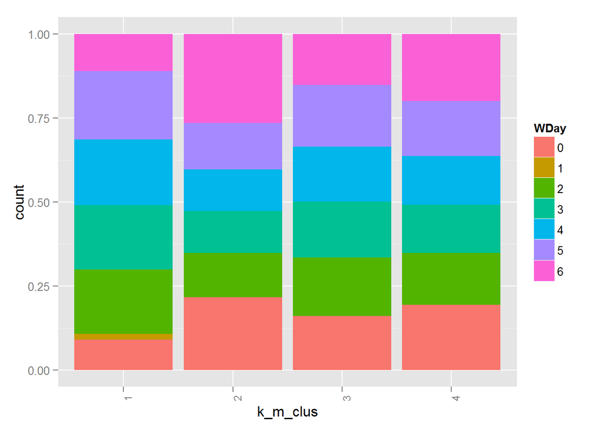

```r
ggplot(data=finalData,aes(x=k_m_clus,fill=WDay))+
  geom_bar(position = "fill")+theme(axis.text.x=element_text(angle=90,size=9))
```

here is the distribution of the visits count in each cluster for each day, the minimum is in the first cluster

# Clustering Using Interactions Dataset

Here we have different approach to use for clustering, We will try to find the similar visitors based on the visited pages for each visitor. then we will cluster these visitors. we beleive that in real life this approach is practical especially for marketing purposes when you can recommend the rest of the visted pages for similar visitors.

we will apply K-means only after finding the best model

## K-means Clustering

```r
clus_range <- seq(3, 20, 1)
col_names_intr <- colnames(finalData_for_interactions)
col_names_intr <- col_names_intr[2:46]
k_meanslst_intr <- list()
for (i in clus_range)
{
  k_meanslst_intr[[i - 2]] <- kmeans(finalData_for_interactions[,col_names_intr], i)
}

#k_meanslst_intr <- k_meanslst_intr [!sapply(k_meanslst_intr, is.null)]
#des <- daisy(as.matrix(finalData_for_interactions[,col_names_intr]))
#kmeans_res_intr <- sapply(k_meanslst_intr, function(x) mean(silhouette(x$cl, des)[, 3]))
#plot(clus_range, kmeans_res_intr)
```

## Choosen Model based on Interactions Dataset and K-means method

```r
k_means_mod_Int <- k_meanslst_intr [[6]]
finalData_for_interactions$k_m_i_clus = factor(k_means_mod_Int$cluster)
ll <-list()
counter = 1
for (cls in  unique(finalData_for_interactions$k_m_i_clus))
{
  temp <- filter(finalData_for_interactions, k_m_i_clus == cls)
  str <- paste("Cluster : ", cls, " Pages : ")
  for (col in col_names_intr)
  {
    su <- sum(temp[, col])
    ll[[counter]] = col
    ll[[counter + 1]] = su
    ll[[counter + 2]] = cls
    counter = counter + 3
    if (su > 15)
    {
      str <- paste(str, " ", col)
    }

  }
}
mat = matrix(data = unlist(ll), ncol = 3, byrow = TRUE)
colnames(mat) <- c("scene", "coun", "cls")
mat <- mat[order(as.numeric(mat[,3]),as.numeric(mat[,2]),decreasing=TRUE),]
```

## Statistcs

### Most Visited Pages For Each Cluster

```r
tot = 1
prev = mat[1,3]
str <- paste("Cluster : ", mat[1, 3], " Pages : ")
for (i in seq(1, nrow(mat),1))
{
  if (mat[i, 3] == prev)
  {
    if (tot < 6)
    {
      str <- paste(str, " ", mat[i, 1])
    }
  }
  else
  {
    print (str)
    str <- paste("Cluster : ", mat[i, 3], " Pages : ")
    prev <- mat[i, 3]
    str <- paste(str, " ", mat[i, 1])
    tot = 1
  }
  tot = tot + 1

}
```

```
## [1] "Cluster :  8  Pages :    Splash   Screen   Main   LevelOne   MainMenu"
## [1] "Cluster :  7  Pages :    ChooseOne   Splash   Evaluation   Screen   removalWarningScene"
## [1] "Cluster :  6  Pages :    Splash   Screen   CustomRemovalWarningScene   Main   Menu"
## [1] "Cluster :  5  Pages :    Splash   Menu   Memory1   Memory2   Memory3"
## [1] "Cluster :  4  Pages :    ComicStripPre   Menu   Splash   ComicStripNext   TakeAPill"
## [1] "Cluster :  3  Pages :    ComicStripPre   Main   Splash   Menu   ComicStripNext"
## [1] "Cluster :  2  Pages :    Main   Splash   AnimalCat   AnimalMan   AnimalDog"
```

### Least Visited Pages For Each Cluster

```r
mat <- mat[order(as.numeric(mat[,3]),as.numeric(mat[,2])),]

tot = 1
prev = mat[1,3]
str <- paste("Cluster : ", mat[1, 3], " Pages : ")
for (i in seq(1, nrow(mat),1))
{
  if (mat[i, 3] == prev)
  {
    if (tot < 6)
    {
      str <- paste(str, " ", mat[i, 1])
    }
  }
  else
  {
    print (str)
    str <- paste("Cluster : ", mat[i, 3], " Pages : ")
    prev <- mat[i, 3]
    str <- paste(str, " ", mat[i, 1])
    tot = 1
  }
  tot = tot + 1

}
```

```
## [1] "Cluster :  1  Pages :    InfoScene   BonusGame   Info1   Attention3   VisualSpatialSense3"
## [1] "Cluster :  2  Pages :    Info1   BonusGame   InfoScene   Attention3   VisualSpatialSense3"
## [1] "Cluster :  3  Pages :    InfoScene   BonusGame   Info1   Attention3   LevelThreeMain"
## [1] "Cluster :  4  Pages :    BonusGame   InfoScene   Attention3   LevelThreeMain   VisualSpatialSense3"
## [1] "Cluster :  5  Pages :    Info1   InfoScene   LevelThreeMain   StroopHighScore   BonusGame"
## [1] "Cluster :  6  Pages :    BonusGame   Info1   InfoScene   Results   Attention3"
## [1] "Cluster :  7  Pages :    BonusGame   Info1   InfoScene   Attention3   VisualSpatialSense3"
```